# IS607 Project 1 Final Version

KarenWeigandt

September 26, 2015

### After the opening ceremonies at the 1996 Summer Olympics, 6 dignitaries are sitting down for a meal and discussion turns to performance at previous Summer Olympics. The dignitaries from Brazil and Denmark begin arguing about which of their countries have performed better over the last 15 years, France and Italy start having the same argument. Romanian and Australian dignitaries are trying to keep the peace, they insist upon looking at the data. All the dignitaries agree on a system of assessment. They will look at the number of medals received by each country in the last 15 years, and each gold medal will be awarded a value of 3 points, each silver 2 points and each bronze just one point. Will the final scores show more medals indicates better performance? Or is it really just gold medals that make the difference? Who had better performance in the contest Brazil vs. Denmark? France vs. Italy?

```r
## Install needed packages
install.packages("XML", dependencies = TRUE, repos = "http://lib.stat.cmu.edu/R/CRAN/")
library(XML)
```

```r
install.packages("ggplot2", dependencies = TRUE, repos = "http://lib.stat.cmu.edu/R/CRAN/")
library(ggplot2)
install.packages("lattice", dependencies = TRUE, repos = "http://lib.stat.cmu.edu/R/CRAN/")
library(lattice)
## 1980
## scrape the webpage into R - 1980 Olympics medals by Country
yr1980 <- "http://www.databasesports.com/olympics/games/gamesyear.htm?g=20"

## Parse the data on the webpage
yr1980_webdata <- readHTMLTable(yr1980, header = TRUE, stringsAsFactors = FALSE)

## Isolate the item of interest - the table that is the 4th element of the website
yr1980_datatable <- yr1980_webdata[4]

## Convert to a data frame
yr1980_dframe <- as.data.frame(yr1980_datatable)

## Change data frame column names
colnames(yr1980_dframe) <- c("Country", "1980.Gold", "1980.Silver", "1980.Bronze", "1980.Total.Medals")

## Change numbers from characters to numerical values
yr1980_dframe$'1980.Gold' <- as.integer(yr1980_dframe$'1980.Gold')
yr1980_dframe$'1980.Silver' <- as.integer(yr1980_dframe$'1980.Silver')
yr1980_dframe$'1980.Bronze' <- as.integer(yr1980_dframe$'1980.Bronze')
yr1980_dframe$`1980.Total.Medals` <- as.integer(yr1980_dframe$`1980.Total.Medals`)

## str(yr1980_dframe)  ## Check structure of the dataframe

## Subset to include just the countries of interest
yr1980_dframe_six_countries <- subset(yr1980_dframe, yr1980_dframe$Country == "France"| yr1980_dframe$Country == "Brazil"| yr1980_dframe$Country == "Denmark"|yr1980_dframe$Country == "Italy"| yr1980_dframe$Country == "Romania"| yr1980_dframe$Country == "Australia")

## Sort countries alphabetically
yr1980_dframe_six_countries <- yr1980_dframe_six_countries[order(yr1980_dframe_six_countries$Country), ]

## Look at data frame
yr1980_dframe_six_countries
```

```
##      Country 1980.Gold 1980.Silver 1980.Bronze 1980.Total.Medals
## 13 Australia         2           2           5                 9
## 20    Brazil         2           0           2                 4
## 17   Denmark         2           1           2                 5
## 11    France         6           5           3                14
## 9      Italy         8           3           4                15
## 6    Romania         6           6          13                25
```

```r
## 1984
## scrape the webpage into R - 1984 Olympics medals by Country
yr1984 <- "http://www.databasesports.com/olympics/games/gamesyear.htm?g=21"

## Parse the data on the webpage
yr1984_webdata <- readHTMLTable(yr1984, header = TRUE, stringsAsFactors = FALSE)

## Isolate the item of interest - the table that is the 4th element of the website
yr1984_datatable <- yr1984_webdata[4]

## Convert to a data frame
yr1984_dframe <- as.data.frame(yr1984_datatable)

## Change data frame column names
colnames(yr1984_dframe) <- c("Country", "1984.Gold", "1984.Silver", "1984.Bronze", "1984.Total.Medals")

## Change numbers from characters to numerical values
yr1984_dframe$'1984.Gold' <- as.integer(yr1984_dframe$'1984.Gold')
yr1984_dframe$'1984.Silver' <- as.integer(yr1984_dframe$'1984.Silver')
yr1984_dframe$'1984.Bronze' <- as.integer(yr1984_dframe$'1984.Bronze')
yr1984_dframe$`1984.Total.Medals` <- as.integer(yr1984_dframe$`1984.Total.Medals`)

## Subset to include just the countries of interest
yr1984_dframe_six_countries <- subset(yr1984_dframe, yr1984_dframe$Country == "France"| yr1984_dframe$Country == "Brazil"| yr1984_dframe$Country == "Denmark"|yr1984_dframe$Country == "Italy"| yr1984_dframe$Country == "Romania"| yr1984_dframe$Country == "Australia")

## Sort countries alphabetically
yr1984_dframe_six_countries <- yr1984_dframe_six_countries[order(yr1984_dframe_six_countries$Country), ]

## View dat frame
yr1984_dframe_six_countries
```

```
##      Country 1984.Gold 1984.Silver 1984.Bronze 1984.Total.Medals
## 10 Australia         4           8          12                24
## 17    Brazil         1           5           2                 8
## 19   Denmark         0           3           3                 6
## 9     France         5           7          16                28
## 7      Italy        14           6          12                32
## 3    Romania        20          16          17                53
```

```r
## Combine the 2 dataframes
olympic_big_dframe <- merge(yr1980_dframe_six_countries, yr1984_dframe_six_countries)

## View newly created dataframe
olympic_big_dframe
```

```
##     Country 1980.Gold 1980.Silver 1980.Bronze 1980.Total.Medals 1984.Gold
## 1 Australia         2           2           5                 9         4
## 2    Brazil         2           0           2                 4         1
## 3   Denmark         2           1           2                 5         0
## 4    France         6           5           3                14         5
## 5     Italy         8           3           4                15        14
## 6   Romania         6           6          13                25        20
##   1984.Silver 1984.Bronze 1984.Total.Medals
## 1           8          12                24
## 2           5           2                 8
## 3           3           3                 6
## 4           7          16                28
## 5           6          12                32
## 6          16          17                53
```

```r
## View only the first row of the dataframe
olympic_big_dframe[1, ]
```

```
##     Country 1980.Gold 1980.Silver 1980.Bronze 1980.Total.Medals 1984.Gold
## 1 Australia         2           2           5                 9         4
##   1984.Silver 1984.Bronze 1984.Total.Medals
## 1           8          12                24
```

```r
## 1988
## scrape the webpage into R - 1988 Olympics medals by Country
yr1988 <- "http://www.databasesports.com/olympics/games/gamesyear.htm?g=22"

## Parse the data on the webpage
yr1988_webdata <- readHTMLTable(yr1988, header = TRUE, stringsAsFactors = FALSE)

## Isolate the item of interest - the table that is the 4th element of the website
yr1988_datatable <- yr1988_webdata[4]

## Convert to a data frame
yr1988_dframe <- as.data.frame(yr1988_datatable)

## Change data frame column names
colnames(yr1988_dframe) <- c("Country", "1988.Gold", "1988.Silver", "1988.Bronze", "1988.Total.Medals")

## Change numbers from characters to numerical values
yr1988_dframe$'1988.Gold' <- as.integer(yr1988_dframe$'1988.Gold')
yr1988_dframe$'1988.Silver' <- as.integer(yr1988_dframe$'1988.Silver')
yr1988_dframe$'1988.Bronze' <- as.integer(yr1988_dframe$'1988.Bronze')
yr1988_dframe$`1988.Total.Medals` <- as.integer(yr1988_dframe$`1988.Total.Medals`)

## str(yr1988_dframe)  ## Check structure of the dataframe

## Subset to include just the countries of interest
yr1988_dframe_six_countries <- subset(yr1988_dframe, yr1988_dframe$Country == "France"| yr1988_dframe$Country == "Brazil"| yr1988_dframe$Country == "Denmark"|yr1988_dframe$Country == "Italy"| yr1988_dframe$Country == "Romania"| yr1988_dframe$Country == "Australia")

## Sort countries alphabetically
yr1988_dframe_six_countries <- yr1988_dframe_six_countries[order(yr1988_dframe_six_countries$Country), ]

## Look at data frame
yr1988_dframe_six_countries
```

```
##      Country 1988.Gold 1988.Silver 1988.Bronze 1988.Total.Medals
## 13 Australia         3           6           5                14
## 23    Brazil         1           2           3                 6
## 25   Denmark         2           1           1                 4
## 11    France         6           4           6                16
## 14     Italy         6           4           4                14
## 9    Romania         7          11           6                24
```

```r
## Combine the 2 dataframes
olympic_big_dframe <- merge(olympic_big_dframe, yr1988_dframe_six_countries)

## View only the first row of the dataframe
olympic_big_dframe[1, ]
```

```
##     Country 1980.Gold 1980.Silver 1980.Bronze 1980.Total.Medals 1984.Gold
## 1 Australia         2           2           5                 9         4
##   1984.Silver 1984.Bronze 1984.Total.Medals 1988.Gold 1988.Silver
## 1           8          12                24         3           6
##   1988.Bronze 1988.Total.Medals
## 1           5                14
```

```r
## 1992
## scrape the webpage into R - 1992 Olympics medals by Country
yr1992 <- "http://www.databasesports.com/olympics/games/gamesyear.htm?g=23"

## Parse the data on the webpage
yr1992_webdata <- readHTMLTable(yr1992, header = TRUE, stringsAsFactors = FALSE)

## Isolate the item of interest - the table that is the 4th element of the website
yr1992_datatable <- yr1992_webdata[4]

## Convert to a data frame
yr1992_dframe <- as.data.frame(yr1992_datatable)

## Change data frame column names
colnames(yr1992_dframe) <- c("Country", "1992.Gold", "1992.Silver", "1992.Bronze", "1992.Total.Medals")

## Change numbers from characters to numerical values
yr1992_dframe$'1992.Gold' <- as.integer(yr1992_dframe$'1992.Gold')
yr1992_dframe$'1992.Silver' <- as.integer(yr1992_dframe$'1992.Silver')
yr1992_dframe$'1992.Bronze' <- as.integer(yr1992_dframe$'1992.Bronze')
yr1992_dframe$`1992.Total.Medals` <- as.integer(yr1992_dframe$`1992.Total.Medals`)

## str(yr1992_dframe)  ## Check structure of the dataframe

## Subset to include just the countries of interest
yr1992_dframe_six_countries <- subset(yr1992_dframe, yr1992_dframe$Country == "France"| yr1992_dframe$Country == "Brazil"| yr1992_dframe$Country == "Denmark"|yr1992_dframe$Country == "Italy"| yr1992_dframe$Country == "Romania"| yr1992_dframe$Country == "Australia")

## Sort countries alphabetically
yr1992_dframe_six_countries <- yr1992_dframe_six_countries[order(yr1992_dframe_six_countries$Country), ]

## Look at data frame
yr1992_dframe_six_countries
```

```
##      Country 1992.Gold 1992.Silver 1992.Bronze 1992.Total.Medals
## 9  Australia         7           9          11                27
## 32    Brazil         2           1           0                 3
## 25   Denmark         1           1           4                 6
## 7     France         8           5          16                29
## 13     Italy         6           5           8                19
## 16   Romania         4           6           8                18
```

```r
## Combine the 2 dataframes
olympic_big_dframe <- merge(olympic_big_dframe, yr1992_dframe_six_countries)

## View only the first row of the dataframe
olympic_big_dframe[1, ]
```

```
##     Country 1980.Gold 1980.Silver 1980.Bronze 1980.Total.Medals 1984.Gold
## 1 Australia         2           2           5                 9         4
##   1984.Silver 1984.Bronze 1984.Total.Medals 1988.Gold 1988.Silver
## 1           8          12                24         3           6
##   1988.Bronze 1988.Total.Medals 1992.Gold 1992.Silver 1992.Bronze
## 1           5                14         7           9          11
##   1992.Total.Medals
## 1                27
```

```r
## Add a column for total Gold medals
olympic_big_dframe$total.Gold <- mapply(sum, olympic_big_dframe$`1980.Gold`, olympic_big_dframe$`1984.Gold`, olympic_big_dframe$`1988.Gold`, olympic_big_dframe$`1992.Gold`)

## Add a column for total Silver medals
olympic_big_dframe$total.Silver <- mapply(sum, olympic_big_dframe$`1980.Silver`, olympic_big_dframe$`1984.Silver`, olympic_big_dframe$`1988.Silver`, olympic_big_dframe$`1992.Silver`)

## Add a column for total Bronze medals
olympic_big_dframe$total.Bronze <- mapply(sum, olympic_big_dframe$`1980.Bronze`, olympic_big_dframe$`1984.Bronze`, olympic_big_dframe$`1988.Bronze`, olympic_big_dframe$`1992.Bronze`)
```

```r
## Calculate total number of medals
olympic_big_dframe$'total.Medals' <- olympic_big_dframe$total.Gold + olympic_big_dframe$total.Silver + olympic_big_dframe$total.Bronze

## Calculate overall score
olympic_big_dframe$Score <- 3 * olympic_big_dframe$total.Gold + 2 * olympic_big_dframe$total.Silver + olympic_big_dframe$total.Bronze

## View updated dataframe
olympic_big_dframe
```

```
##     Country 1980.Gold 1980.Silver 1980.Bronze 1980.Total.Medals 1984.Gold
## 1 Australia         2           2           5                 9         4
## 2    Brazil         2           0           2                 4         1
## 3   Denmark         2           1           2                 5         0
## 4    France         6           5           3                14         5
## 5     Italy         8           3           4                15        14
## 6   Romania         6           6          13                25        20
##   1984.Silver 1984.Bronze 1984.Total.Medals 1988.Gold 1988.Silver
## 1           8          12                24         3           6
## 2           5           2                 8         1           2
## 3           3           3                 6         2           1
## 4           7          16                28         6           4
## 5           6          12                32         6           4
## 6          16          17                53         7          11
##   1988.Bronze 1988.Total.Medals 1992.Gold 1992.Silver 1992.Bronze
```

[output cut: 20 more lines]

```r
## Write data frame to a csv file that will be saved in the current directory
write.csv(olympic_big_dframe, file = "olympic_big_dframe.csv", row.names = FALSE)
```

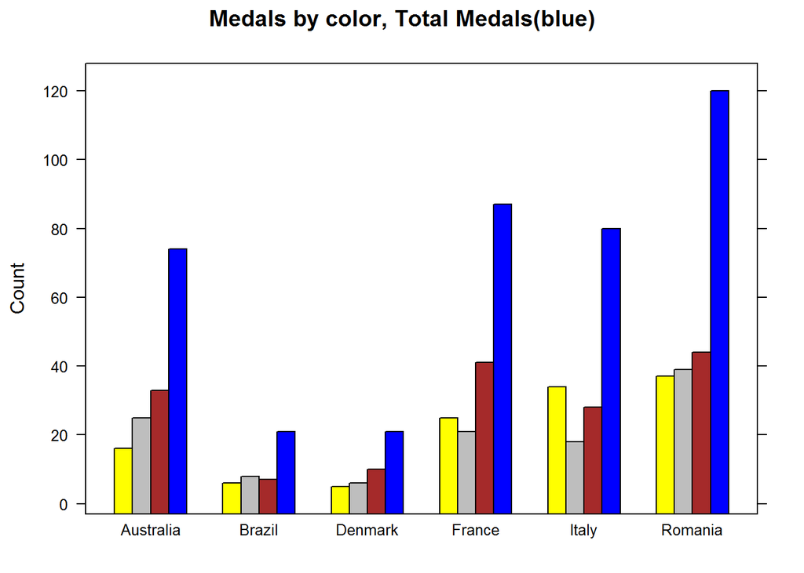

```r
##  Graphics
## Create a colorscheme variable
mycol = c("yellow","gray","brown", "blue")

## Barchart for all countries
barchart(`total.Gold`+`total.Silver`+`total.Bronze`+`total.Medals`~Country,data=olympic_big_dframe, col = mycol,  main = "Medals by color, Total Medals(blue)", ylab ="Count")
```

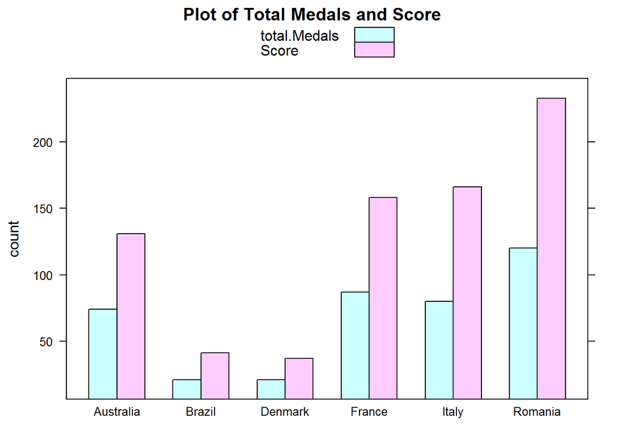

```r
## Barchart showing the individual medals and the medal total
barchart(`total.Medals`+`Score`~Country,
         data=olympic_big_dframe,
         auto.key = TRUE,
         ylab = "count",
         main = "Plot of Total Medals and Score")
```

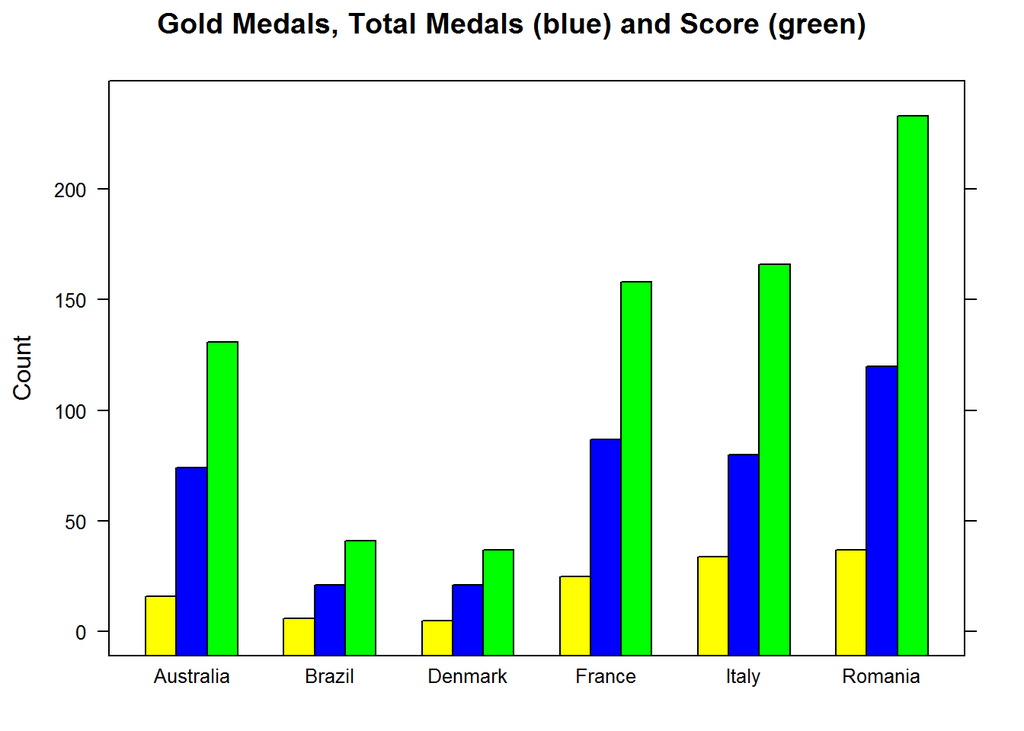

```r
## Create another colorscheme variable
mycol3 <- c("yellow", "blue", "green")

## Barchart showing the medal total and the calculated score
barchart(`total.Gold`+`total.Medals`+`Score`~Country,
         data=olympic_big_dframe,
         col = mycol3,
         ylab = "Count",
         main = "Gold Medals, Total Medals (blue) and Score (green)")
```

### We will zoom in on the countries in question for a better view

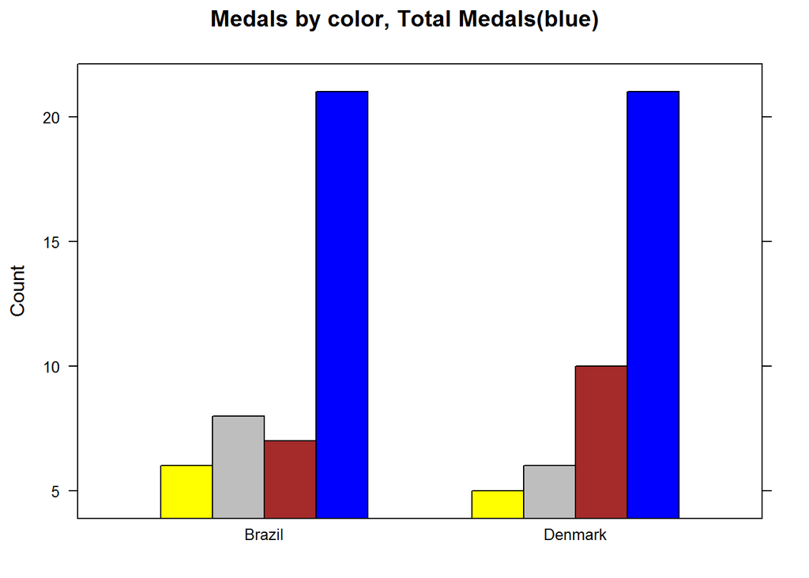

```r
## Brazil and Denmark isolated for better view
## Create dataframe including just these 2 countries
bd_olympic_dframe <- subset(olympic_big_dframe, olympic_big_dframe$Country == "Brazil"| olympic_big_dframe$Country == "Denmark")

## Barchart showing the individual medals and the medal total
barchart(`total.Gold`+`total.Silver`+`total.Bronze`+`total.Medals`~Country,data=bd_olympic_dframe, col = mycol, main = "Medals by color, Total Medals(blue)", ylab ="Count")
```

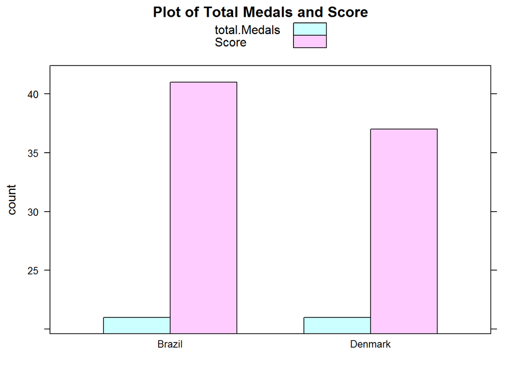

```r
## Barchart showing the medal total and the calculated score
barchart(`total.Medals`+`Score`~Country,
         data=bd_olympic_dframe,
         auto.key = TRUE, ylab = "count",
         main = "Plot of Total Medals and Score")
```

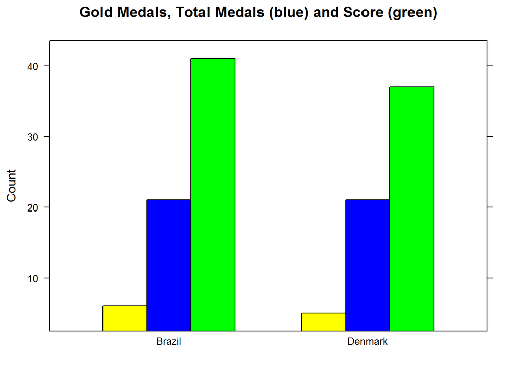

```r
## Barchart showing the medal total and the calculated score
barchart(`total.Gold`+`total.Medals`+`Score`~Country,
         data=bd_olympic_dframe,
         col = mycol3,
         ylab = "Count",
         main = "Gold Medals, Total Medals (blue) and Score (green)")
```

### Brazil and Denmark won the same number of medals, but Brazil has a higher score because more of their medals were gold.

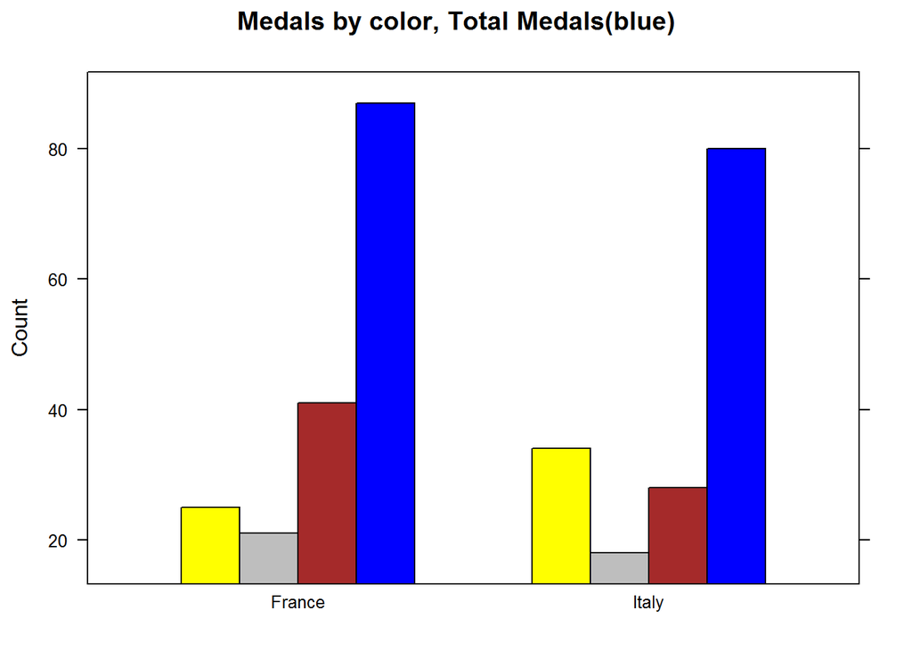

```r
## France and Italy isolated for better view
## Create dataframe including just these 2 countries
bd_olympic_dframe <- subset(olympic_big_dframe, olympic_big_dframe$Country == "France"| olympic_big_dframe$Country == "Italy")

## Barchart showing the individual medals and the medal total
barchart(`total.Gold`+`total.Silver`+`total.Bronze`+`total.Medals`~Country,data=bd_olympic_dframe, col = mycol, main = "Medals by color, Total Medals(blue)", ylab ="Count")
```

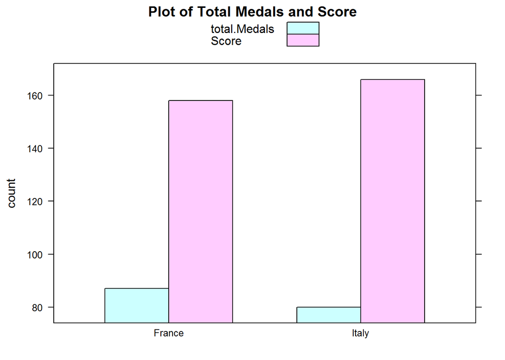

```r
## Barchart showing the medal total and the calculated score
barchart(`total.Medals`+`Score`~Country,
         data=bd_olympic_dframe,
         auto.key = TRUE, ylab = "count",
         main = "Plot of Total Medals and Score")
```

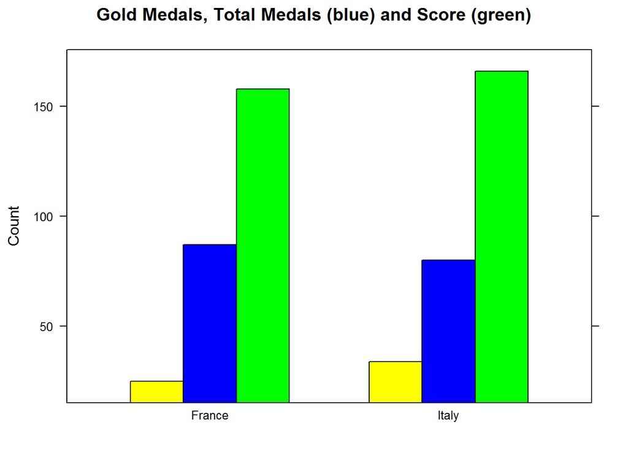

```r
## Barchart showing the medal total and the calculated score
barchart(`total.Gold`+`total.Medals`+`Score`~Country,
         data=bd_olympic_dframe,
         col = mycol3,
         ylab = "Count",
         main = "Gold Medals, Total Medals (blue) and Score (green)")
```

### Italy won more gold medals, but the total number of medals won by France is higher. Italy still has a higher calculated score.

### The results here provide an indication that the number of medals won is not always the best predictor of performance based on the assessment tool devised here. In this instance, gold appears to be the gold standard!